# Reconhecimento de Padrões - T1

# 1. Introdução

Neste trabalho iremos analizar dados de pacientes, para classificarmos pacientes com parkinsons.

Serão utilizadas várias técnicas de classificação, assim como técnicas de transformação dos dados que permitem a redução de dimensionalidade do dado preservando alguns aspectos dele, como sua variância ou separação entre classes.

Este trabalho foi feito de forma bem modular, a ponto de ser possível reutilizar muitos dos modelos para outros trabalhos. Além disso foram utilizadas algumas bibliotecas de manipulação de matrizes e visualização de dados.

```python
import tester
import datasets
import importlib
import models
import utils
import matplotlib.pyplot as plt
%matplotlib inline
```

# 2. Dataset

O dataset possui 195 entradas com 22 atributos cada e 1 atributo que indica se o paciente possui ou não parkinsons

Além disso, é feita uma normalização estatística dos dados para prevenir valores muito grandes ou muito pequenos que possam atrapalhar os modelos de classificação, além de tornar a comparação entre diferentes atributos mais relativas ao invés de absolutas.

```python
data = datasets.parkinsons(normalized=True)
print(data.X.shape)
```

```
(195, 22)
```

Como podemos ver a seguir, os dados são bem desbalanceados, onde '0' representa pacientes sem parkinsons e '1' são os que possuem parkinsons.

São aproximadamente 75% de pacientes com parkinsons e 25% sem.

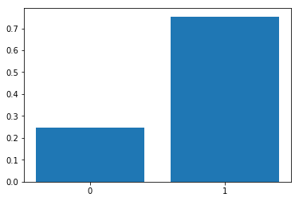

```python
plt.bar([0, 1], np.bincount(data.Y) / len(data.Y))
plt.xticks([0, 1])
plt.show()
```

## 2.1. Transformação dos dados

Para uma visualização dos dados em 2 dimensões podemos utilizar PCA ou LDA.

Para isso foi criada uma classe de transformação de dados que será a base para as 2 técnicas.

```python
class Transformer:

    def __init__(self):
        self.eig_vals = None
        self.T = None

    def transform(self, X, min_var):
        if self.T is None:
            print('Not Fit')
            return
        cs = np.cumsum(self.eig_vals / self.eig_vals.sum())
        n_components = len([x for x in cs if x < min_var]) + 1
        subT = self.T[:, :n_components]
        return np.matmul(X, subT)
```

#### PCA:

```python
class PCA(Transformer):

    def fit(self, X, Y=None):
        vals, vecs = np.linalg.eig(cov(X))
        idx = vals.argsort()[::-1]
        self.eig_vals, self.T = vals[idx], np.real(vecs[:, idx])
```

Transformando os dados com ~60% de variância preservada:

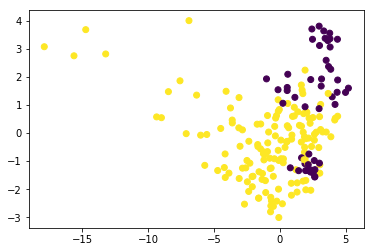

```python
pca = utils.PCA()
pca.fit(data.X)
X_ = pca.transform(data.X, min_var=0.6)
plt.scatter(X_[:, 0], X_[:, 1], c=data.Y)
plt.show()
```

#### LDA:

```python
class LDA(Transformer):

    def fit(self, X, Y):

        cd = to_class_dict(X, Y)
        classes = [cd[y] for y in sorted(cd)]

        m = np.mean(np.array([x for c in classes for x in c]), axis=0)
        centroids = [np.mean(c, axis=0) for c in classes]
        covariances = [cov(c) for c in classes]

        Sw = sum([len(classes[i]) * covariances[i] for i in range(len(classes))])
        Sw_inv = np.linalg.inv(Sw)
        n_m = [(c - m).reshape(1, -1) for c in centroids]
        Sb = sum([np.dot(n_m[i].T, n_m[i]) for i in range(len(classes))])

        vals, vecs = np.linalg.eig(np.dot(Sw_inv, Sb))
        idx = vals.argsort()[::-1]
        self.eig_vals, self.T = vals[idx], np.real(vecs[:, idx])
```

Transformando os dados com quase toda a separação das classes preservada:

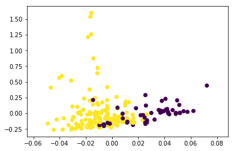

```python
lda = utils.LDA()
lda.fit(data.X, data.Y)
X_ = lda.transform(data.X, min_var=0.9999999999999999)
plt.scatter(X_[:, 0], X_[:, 1], c=data.Y)
plt.show()
```

# 3. Modelos de classificação

Todos os modelos de classificação seguem o mesmo padrão, de treinar com a matriz de dados e o vetor de classes, e retornar as classes preditas passando uma matriz onde cada linha é um vetor de atributos. Este padrão é o mesmo utilizado pelos modelos das bibliotecas do Python, permitindo a utilização delas em nossos testes.

Estes modelos se encontram no arquivo "models.py" e serão reapresentados neste documento.

## 3.1. KNN (K - Nearest Neighbors)

Para o KNN, foi utilizada uma KDTree, que é um tipo de estrutura de indexação espacial, para acelerar a busca pelos vizinhos mais próximos. O retorno da busca são tuplas representando os vizinhos, cada uma com a distância para o vizinho e a posição no vetor dele, permitindo assim saber a classe desses vizinhos.

```python
class KNN:

    def __init__(self, k=1):
        self.k = k
        self.X = None
        self.Y = None
        self.kdTree = None

    def fit(self, X_train, Y_train):
        self.X = X_train
        self.Y = Y_train
        self.kdTree = spatial.cKDTree(self.X, leafsize=10)

    def predict(self, X):
        if self.X is None:
            raise Exception('Not trained')
        return [self.__predict_one(x) for x in X]

    def __predict_one(self, x):
        query = self.kdTree.query(x, k=self.k)
        if self.k == 1:
            return self.Y[query[1]]
        classes = np.array([self.Y[i] for i in query[1]])
        return np.bincount(classes).argmax()
```

## 3.2. NN (Nearest Neighbor)

Como o NN é o caso particular do KNN, podemos utilizá-lo simplesmente como:

```python
NN = models.KNN(k=1)
```

## 3.3. DMC (Distância Mínima ao Centroide)

```python
class DMC:

    def __init__(self):
        self.clusters = {}
        self.centroids = None

    def fit(self, X_train, Y_train):
        self.clusters = utils.to_class_dict(X_train, Y_train)
        self.centroids = {k : np.mean(self.clusters[k], axis=0) for k in self.clusters}

    def predict(self, X):
        if self.centroids is None:
            raise Exception('Not trained')
        return [self.__predict_one(x) for x in X]

    def __predict_one(self, x):
        return min(self.centroids, key=lambda c : utils.distance(self.centroids[c], x))
```

## 3.4. CQG (Classificador Quadrático Gaussiano)

Para este classificador, a função de densidade de probabilidade para calcular a probabilidade à posteriori é uma gaussiana, logo foi criada a classe Gaussian para facilitar o manuseio do modelo.

Como pode-se perceber, para a classificação é utilizado o logarítimo da gaussiana que facilita os cálculos, além de cancelar vários termos da desigualdade para determinar a classe do dado.

```python
class Gaussian:
    def __init__(self, X, naive=False):
        self.X = X
        self.n = len(X)
        self.mean = np.mean(X, axis=0)
        c = utils.cov(X)
        if naive:
            c = np.multiply(c, np.eye(c.shape[0]))
        self.update_cov(c)

    def singular(self):
        return np.linalg.matrix_rank(self.cov) != self.cov.shape[0]

    def update_cov(self, cov):
        self.cov = cov
        self.cov_inv = np.linalg.pinv(cov)
        self.cov_det = np.linalg.det(cov)

    def log_prob(self, x):
        z = x - self.mean
        return - 0.5 * (np.dot(z, np.dot(self.cov_inv, z)) + np.log(self.cov_det))
```

Podemos também perceber que é utilizada a inversa da matriz de covariância, que caso seja uma matriz singular, não possui inversa. Logo, para tentar driblar este problema podem ser utilizadas utilizadas as técnicas Pooled e Friedman.

```python
def pooled_cov(gaussians):
    return np.average([g.cov for g in gaussians], axis=0, weights=[g.n for g in gaussians])

def __friedman_for_gaussian(g, total, pooled, alpha):
    return np.average(np.array([cov, pooled]), axis=0, weights=[(1 - alpha) * g.n, alpha * total])

def apply_friedman(gaussians, alpha):
    total = sum([g.n for g in gaussians])
    pooled = pooled_cov(gaussians)
    for g in gaussians:
        g.update_cov(__friedman_for_gaussian(g, total, pooled, alpha))
```

Com isso, vemos que Pooled é um caso particular de Friedman onde alpha = 1, logo não é necessária a distinção no código deixando-o mais limpo.

```python
class CQG:

    def __init__(self, naive=False, friedman_value=0.3):
        self.gaussians = None
        self.a_priori = None
        self.naive = naive

    def a_posteriori(self, x):
        return np.array([g.log_prob(x) for g in self.gaussians])

    def fit(self, X_train, Y_train):
        cd = utils.to_class_dict(X_train, Y_train)
        self.gaussians = [utils.Gaussian(cd[y], self.naive) for y in sorted(cd)]

        if any([g.singular() for g in self.gaussians]):
            utils.apply_friedman(self.gaussians, friedman_value)

        self.a_priori = np.array([ np.log(g.n) for g in self.gaussians ])

    def predict(self, X):
        if self.gaussians is None:
            raise Exception('Not trained')
        return [self.__predict_one(x) for x in X]

    def __predict_one(self, x):
        probabilities = self.a_priori + self.a_posteriori(x)
        return probabilities.argmax()
```

## 3.5. GNB (Gaussian Naive Bayes)

Como vimos no modelo anterior, existe uma variável chamada "naive", ao utilizá-la, todos os elementos fora das diagonais principais das matrizes de covariância das gaussianas são zerados, removendo assim as correlações entre atributos diferentes.

Ele pode ser utilizado simplesmente como:

```python
gnb = models.CQG(naive=True)
```

## 3.6. MLP (Multi Layer Perceptron)

Para fins de comparação, foi utilizado um MLP de uma biblioteca do python já que o MLP é um modelo muito versátil e normalmente se adapta bem a dados complexos como estes.

```python
from sklearn.neural_network import MLPClassifier
class MLP:

    def __init__(self, layers=(10, 3), max_iter=200):
        self.X = None
        self.Y = None
        self.mlp = MLPClassifier(hidden_layer_sizes=layers, max_iter=max_iter)

    def fit(self, X, Y):
        self.mlp.fit(X, Y)

    def predict(self, X):
        return self.mlp.predict(X)
```

# 4. Testes

Para os testes, foi construída uma classe para facilitar o teste de qualquer modelo. Esta classe permite testar até modelos das próprias bibliotecas de aprendizado do python, além de gerar suas estatísticas.

```python
class Tester:

    def __init__(self, dataset, model):
        self.model = model
        self.dataset = dataset
        self.conf_matrices = []

    def test(self, n_tests=100, transform=None, min_transform_var=0.999):
        for _ in range(n_tests):
            X_train, Y_train, X_test, Y_test = self.dataset.get_random_train_test()

            if transform:
                transform.fit(X_train, Y_train)
                X_train = transform.transform(X_train, min_transform_var)
                X_test = transform.transform(X_test, min_transform_var)

            model = deepcopy(self.model)
            model.fit(X_train, Y_train)

            cm = np.zeros((2, 2))

            preds = model.predict(X_test)

            for y, pred in zip(Y_test, preds):
                cm[y, pred] += 1

            self.conf_matrices.append(cm)

    def statistics(self):
        return Statistics(self)

class Statistics:
    def __init__(self, tester):
        if not tester.conf_matrices:
            print('Not tested')
        else:
            self.ms = np.array(tester.conf_matrices)
            self.m_sum = self.ms.sum(axis=0)
            self.accs = np.array([m.trace() / m.sum() for m in self.ms])

    def acc_mean(self):
        return np.mean(self.accs)

    def acc_median(self):
        return np.median(self.accs)

    def acc_max(self):
        return np.max(self.accs)

    def acc_min(self):
        return np.min(self.accs)

    def acc_std(self):
        return np.std(self.accs)

    def specificity(self):
        return self.m_sum[0, 0] / self.m_sum.sum(axis=0)[0]

    def sensibility(self):
        return self.m_sum[1, 1] / self.m_sum.sum(axis=0)[1]

    def get_values(self):
        return [self.acc_mean(), self.acc_median(), self.acc_min(), self.acc_max(), self.acc_std(), self.specificity(), self.sensibility()]
```

Iremos guardar cada estatística neste dicionário

```python
all_statistics = {}
```

## 4.1. Sem Transformações

### 4.1.1. KNN(5)

```python
m_tester = tester.Tester(datasets.parkinsons(True), models.KNN(k=5))
m_tester.test(transform=None)
stats = m_tester.statistics()
all_statistics['knn_5'] = stats.get_values()
stats.print_all()
```

```
Test Accuracy:
```

| Mean | Median | Min | Max | STD | Specificity | Sensibility |
| --- | --- | --- | --- | --- | --- | --- |
| 0.9 | 0.9 | 0.77 | 0.97 | 0.04 | 0.82 | 0.93 |

### 4.1.2. KNN(9)

```python
m_tester = tester.Tester(datasets.parkinsons(True), models.KNN(k=9))
m_tester.test(transform=None)
stats = m_tester.statistics()
all_statistics['knn_9'] = stats.get_values()
stats.print_all()
```

```
Test Accuracy:
```

| Mean | Median | Min | Max | STD | Specificity | Sensibility |
| --- | --- | --- | --- | --- | --- | --- |
| 0.88 | 0.88 | 0.77 | 0.97 | 0.05 | 0.81 | 0.9 |

### 4.1.3. NN

```python
m_tester = tester.Tester(datasets.parkinsons(True), models.KNN(k=1))
m_tester.test(transform=None)
stats = m_tester.statistics()
all_statistics['nn'] = stats.get_values()
stats.print_all()
```

```
Test Accuracy:
```

| Mean | Median | Min | Max | STD | Specificity | Sensibility |
| --- | --- | --- | --- | --- | --- | --- |
| 0.94 | 0.95 | 0.82 | 1.0 | 0.04 | 0.84 | 0.98 |

### 4.1.4. DMC

```python
m_tester = tester.Tester(datasets.parkinsons(True), models.DMC())
m_tester.test(transform=None)
stats = m_tester.statistics()
all_statistics['dmc'] = stats.get_values()
stats.print_all()
```

```
Test Accuracy:
```

| Mean | Median | Min | Max | STD | Specificity | Sensibility |
| --- | --- | --- | --- | --- | --- | --- |
| 0.73 | 0.74 | 0.56 | 0.87 | 0.07 | 0.47 | 0.95 |

### 4.1.5. CQG

```python
m_tester = tester.Tester(datasets.parkinsons(True), models.CQG(friedman_value=0.5))
m_tester.test(transform=None)
stats = m_tester.statistics()
all_statistics['cqg'] = stats.get_values()
stats.print_all()
```

```
Test Accuracy:
```

| Mean | Median | Min | Max | STD | Specificity | Sensibility |
| --- | --- | --- | --- | --- | --- | --- |
| 0.88 | 0.87 | 0.72 | 1.0 | 0.05 | 0.87 | 0.88 |

### 4.1.6. GNB

```python
m_tester = tester.Tester(datasets.parkinsons(True), models.CQG(naive=True))
m_tester.test(transform=None)
stats = m_tester.statistics()
all_statistics['gnb'] = stats.get_values()
stats.print_all()
```

```
Test Accuracy:
```

| Mean | Median | Min | Max | STD | Specificity | Sensibility |
| --- | --- | --- | --- | --- | --- | --- |
| 0.7 | 0.69 | 0.54 | 0.9 | 0.07 | 0.45 | 0.95 |

### 4.1.7. MLP (100, 50, 20, 10)

Foram testados alguns outros valores para a quantidade de nós nas camadas internas e a quantidade de camadas internas, este foi um dos melhores resultados, o que indica que os dados são extremamente complexos e a superfície de separação deles não é bem comportada.

```python
m_tester = tester.Tester(datasets.parkinsons(True), models.MLP(layers=(100, 50, 20, 10), max_iter=3000))
m_tester.test(transform=None)
stats = m_tester.statistics()
all_statistics['mlp'] = stats.get_values()
stats.print_all()
```

```
Test Accuracy:
```

| Mean | Median | Min | Max | STD | Specificity | Sensibility |
| --- | --- | --- | --- | --- | --- | --- |
| 0.93 | 0.92 | 0.79 | 1.0 | 0.04 | 0.87 | 0.94 |

## 4.2. Using PCA

### 4.2.1. KNN(5)

```python
m_tester = tester.Tester(datasets.parkinsons(True), models.KNN(k=5))
m_tester.test(transform=utils.PCA())
stats = m_tester.statistics()
all_statistics['knn_5_pca'] = stats.get_values()
stats.print_all()
```

```
Test Accuracy:
```

| Mean | Median | Min | Max | STD | Specificity | Sensibility |
| --- | --- | --- | --- | --- | --- | --- |
| 0.9 | 0.9 | 0.79 | 1.0 | 0.04 | 0.82 | 0.93 |

### 4.2.2. KNN(9)

```python
m_tester = tester.Tester(datasets.parkinsons(True), models.KNN(k=9))
m_tester.test(transform=utils.PCA())
stats = m_tester.statistics()
all_statistics['knn_9_pca'] = stats.get_values()
stats.print_all()
```

```
Test Accuracy:
```

| Mean | Median | Min | Max | STD | Specificity | Sensibility |
| --- | --- | --- | --- | --- | --- | --- |
| 0.88 | 0.9 | 0.62 | 1.0 | 0.06 | 0.87 | 0.88 |

### 4.2.3. NN

```python
m_tester = tester.Tester(datasets.parkinsons(True), models.KNN(k=1))
m_tester.test(transform=utils.PCA())
stats = m_tester.statistics()
all_statistics['nn_pca'] = stats.get_values()
stats.print_all()
```

```
Test Accuracy:
```

| Mean | Median | Min | Max | STD | Specificity | Sensibility |
| --- | --- | --- | --- | --- | --- | --- |
| 0.93 | 0.95 | 0.82 | 1.0 | 0.04 | 0.81 | 0.97 |

### 4.2.4. DMC

```python
m_tester = tester.Tester(datasets.parkinsons(True), models.DMC())
m_tester.test(transform=utils.PCA())
stats = m_tester.statistics()
all_statistics['dmc_pca'] = stats.get_values()
stats.print_all()
```

```
Test Accuracy:
```

| Mean | Median | Min | Max | STD | Specificity | Sensibility |
| --- | --- | --- | --- | --- | --- | --- |
| 0.75 | 0.74 | 0.62 | 0.95 | 0.06 | 0.49 | 0.95 |

### 4.2.5. CQG

```python
m_tester = tester.Tester(datasets.parkinsons(True), models.CQG(friedman_value=0.5))
m_tester.test(transform=utils.PCA())
stats = m_tester.statistics()
all_statistics['cqg_pca'] = stats.get_values()
stats.print_all()
```

```
Test Accuracy:
```

| Mean | Median | Min | Max | STD | Specificity | Sensibility |
| --- | --- | --- | --- | --- | --- | --- |
| 0.86 | 0.87 | 0.69 | 1.0 | 0.06 | 0.74 | 0.89 |

### 4.2.6. GNB

```python
m_tester = tester.Tester(datasets.parkinsons(True), models.CQG(naive=True))
m_tester.test(transform=utils.PCA())
stats = m_tester.statistics()
all_statistics['gnb_pca'] = stats.get_values()
stats.print_all()
```

```
Test Accuracy:
```

| Mean | Median | Min | Max | STD | Specificity | Sensibility |
| --- | --- | --- | --- | --- | --- | --- |
| 0.78 | 0.79 | 0.64 | 0.9 | 0.06 | 0.53 | 0.89 |

### 4.2.7. MLP (100, 50, 20, 10)

```python
m_tester = tester.Tester(datasets.parkinsons(True), models.MLP(layers=(100, 50, 20, 10), max_iter=3000))
m_tester.test(transform=utils.PCA())
stats = m_tester.statistics()
all_statistics['mlp_pca'] = stats.get_values()
stats.print_all()
```

```
Test Accuracy:
```

| Mean | Median | Min | Max | STD | Specificity | Sensibility |
| --- | --- | --- | --- | --- | --- | --- |
| 0.93 | 0.92 | 0.79 | 1.0 | 0.04 | 0.86 | 0.95 |

## 4.3. Using LDA

### 4.3.1. KNN(5)

```python
m_tester = tester.Tester(datasets.parkinsons(True), models.KNN(k=5))
m_tester.test(transform=utils.LDA())
stats = m_tester.statistics()
all_statistics['knn_5_lda'] = stats.get_values()
stats.print_all()
```

```
Test Accuracy:
```

| Mean | Median | Min | Max | STD | Specificity | Sensibility |
| --- | --- | --- | --- | --- | --- | --- |
| 0.87 | 0.87 | 0.77 | 1.0 | 0.05 | 0.79 | 0.89 |

### 4.3.2. KNN(9)

```python
m_tester = tester.Tester(datasets.parkinsons(True), models.KNN(k=9))
m_tester.test(transform=utils.LDA())
stats = m_tester.statistics()
all_statistics['knn_9_lda'] = stats.get_values()
stats.print_all()
```

```
Test Accuracy:
```

| Mean | Median | Min | Max | STD | Specificity | Sensibility |
| --- | --- | --- | --- | --- | --- | --- |
| 0.87 | 0.87 | 0.74 | 0.97 | 0.05 | 0.81 | 0.88 |

### 4.3.3. NN

```python
m_tester = tester.Tester(datasets.parkinsons(True), models.KNN(k=1))
m_tester.test(transform=utils.LDA())
stats = m_tester.statistics()
all_statistics['nn_lda'] = stats.get_values()
stats.print_all()
```

```
Test Accuracy:
```

| Mean | Median | Min | Max | STD | Specificity | Sensibility |
| --- | --- | --- | --- | --- | --- | --- |
| 0.82 | 0.82 | 0.69 | 0.92 | 0.05 | 0.64 | 0.88 |

### 4.3.4. DMC

```python
m_tester = tester.Tester(datasets.parkinsons(True), models.DMC())
m_tester.test(transform=utils.LDA())
stats = m_tester.statistics()
all_statistics['dmc_lda'] = stats.get_values()
stats.print_all()
```

```
Test Accuracy:
```

| Mean | Median | Min | Max | STD | Specificity | Sensibility |
| --- | --- | --- | --- | --- | --- | --- |
| 0.83 | 0.82 | 0.72 | 0.95 | 0.05 | 0.61 | 0.92 |

### 4.3.5. CQG

```python
m_tester = tester.Tester(datasets.parkinsons(True), models.CQG(friedman_value=0.5))
m_tester.test(transform=utils.LDA())
stats = m_tester.statistics()
all_statistics['cqg_lda'] = stats.get_values()
stats.print_all()
```

```
Test Accuracy:
```

| Mean | Median | Min | Max | STD | Specificity | Sensibility |
| --- | --- | --- | --- | --- | --- | --- |
| 0.86 | 0.87 | 0.69 | 0.97 | 0.06 | 0.77 | 0.89 |

### 4.3.6. GNB

```python
m_tester = tester.Tester(datasets.parkinsons(True), models.CQG(naive=True))
m_tester.test(transform=utils.LDA())
stats = m_tester.statistics()
all_statistics['gnb_lda'] = stats.get_values()
stats.print_all()
```

```
Test Accuracy:
```

| Mean | Median | Min | Max | STD | Specificity | Sensibility |
| --- | --- | --- | --- | --- | --- | --- |
| 0.87 | 0.87 | 0.74 | 0.97 | 0.05 | 0.78 | 0.89 |

### 4.3.7. MLP (100, 50, 20, 10)

Neste caso o MLP sofreu mais, já que ele consegue muito bem criar superfícies de separação complexas em muitas dimensões e ele perde muito com essa redução de dimensionalidade.

```python
m_tester = tester.Tester(datasets.parkinsons(True), models.MLP(layers=(100, 50, 20, 10), max_iter=3000))
m_tester.test(transform=utils.LDA())
stats = m_tester.statistics()
all_statistics['mlp_lda'] = stats.get_values()
stats.print_all()
```

```
Test Accuracy:
```

| Mean | Median | Min | Max | STD | Specificity | Sensibility |
| --- | --- | --- | --- | --- | --- | --- |
| 0.76 | 0.77 | 0.62 | 0.9 | 0.07 | 0.84 | 0.76 |

## 4.4. Todos os testes

```python
from IPython.display import display, HTML
import numpy as np
import pandas as pd
import seaborn as sns
pd.set_option("display.precision", 2)

ordered_stats = {k: all_statistics[k] for k in sorted(all_statistics, key=lambda x : all_statistics[x][0], reverse=True)}

cols = ['Mean', 'Median', 'Min', 'Max', 'STD', 'Specificity', 'Sensibility']

df = pd.DataFrame.from_dict(ordered_stats, orient='index', columns=cols)

th_props = [('font-size', '14px'),('text-align', 'center'),
            ('font-weight', 'bold'),('color', '#6d6d6d'),('background-color', '#DDD')]

# Set CSS properties for td elements in dataframe
td_props = [('font-size', '14px'),('text-align', 'center')]

# Set table styles
styles = [dict(selector="th", props=th_props), dict(selector="td", props=td_props)]

df.style.format({k:"{:.1%}" for k in cols if k != 'STD'}).set_table_styles(styles)
```

|  | Mean | Median | Min | Max | STD | Specificity | Sensibility |
| --- | --- | --- | --- | --- | --- | --- | --- |
| nn | 93.9% | 94.9% | 82.1% | 100.0% | 0.039 | 83.7% | 97.6% |
| nn_pca | 93.1% | 94.9% | 82.1% | 100.0% | 0.039 | 81.5% | 97.5% |
| mlp_pca | 92.8% | 92.3% | 79.5% | 100.0% | 0.039 | 85.7% | 95.0% |
| mlp | 92.5% | 92.3% | 79.5% | 100.0% | 0.041 | 87.0% | 94.1% |
| knn_5 | 90.4% | 89.7% | 76.9% | 97.4% | 0.044 | 82.2% | 93.1% |
| knn_5_pca | 90.4% | 89.7% | 79.5% | 100.0% | 0.043 | 82.2% | 92.9% |
| knn_9 | 88.2% | 88.5% | 76.9% | 97.4% | 0.048 | 80.6% | 89.9% |
| cqg | 88.2% | 87.2% | 71.8% | 100.0% | 0.054 | 86.8% | 88.5% |
| knn_9_pca | 87.7% | 89.7% | 61.5% | 100.0% | 0.06 | 86.6% | 87.9% |
| knn_5_lda | 87.1% | 87.2% | 76.9% | 100.0% | 0.052 | 79.0% | 89.0% |
| gnb_lda | 87.0% | 87.2% | 74.4% | 97.4% | 0.052 | 77.7% | 89.4% |
| knn_9_lda | 86.9% | 87.2% | 74.4% | 97.4% | 0.05 | 81.4% | 88.2% |
| cqg_lda | 86.4% | 87.2% | 69.2% | 97.4% | 0.055 | 77.3% | 88.7% |
| cqg_pca | 86.0% | 87.2% | 69.2% | 100.0% | 0.06 | 74.4% | 89.4% |
| dmc_lda | 82.8% | 82.1% | 71.8% | 94.9% | 0.049 | 60.9% | 92.1% |
| nn_lda | 82.4% | 82.1% | 69.2% | 92.3% | 0.053 | 64.0% | 88.2% |
| gnb_pca | 78.2% | 79.5% | 64.1% | 89.7% | 0.056 | 53.4% | 89.0% |
| mlp_lda | 76.3% | 76.9% | 61.5% | 89.7% | 0.065 | 83.9% | 76.3% |
| dmc_pca | 74.9% | 74.4% | 61.5% | 94.9% | 0.056 | 49.4% | 95.0% |
| dmc | 73.1% | 74.4% | 56.4% | 87.2% | 0.067 | 46.7% | 94.7% |
| gnb | 70.2% | 69.2% | 53.8% | 89.7% | 0.07 | 45.0% | 94.8% |

## 5. Conclusão

Podemos perceber que o NN e o MLP são os melhores classificadores para este dataset, com o NN ganhando a disputa, mas existem alguns detalhes que são importantes ressaltar. Quanto à sensibilidade, o NN é sem dúvidas o melhor, já o MLP ganha de todos na especificidade.

Em um caso de diagnóstico como este, é muito melhor termos mais falsos positivos que falsos negativos, logo para este problema, NN é sem dúvidas o melhor classificador, mas há algo muito importante que precisa ser relatado. Este dataset é construído a partir de testes em pacientes, mas ao mesmo paciente são feitos mais de 1 teste. Com isso, é muito provável que o NN esteja classificando vizinhos próximos que são da mesma pessoa, que não reflete a realidade

Aqui é apresentado um teste pegando as médias dos resultados de cada paciente, já que provavelmente isso seria mais próximo de uma classificação realística.

[figure not shown]

```python
df = pd.read_csv('data/parkinsons.csv', index_col='name')
data_dict = {idx: list(cols) for idx, cols in df.iterrows()}

compact = {}
for name in data_dict:
    clear_name = name[:-2]
    if clear_name not in compact:
        compact[clear_name] = []
    compact[clear_name].append(data_dict[name])

final_data = np.array([np.mean(np.array(x), axis=0) for x in compact.values()])
X = np.delete(final_data, 16, axis=1)
Y = final_data[:, 16].astype(int)

clear_dataset = datasets.Dataset(X, Y, True)

pca = utils.LDA()
pca.fit(clear_dataset.X, clear_dataset.Y)
X_ = pca.transform(clear_dataset.X, min_var=0.99999999)
plt.scatter(X_[:, 0], X_[:, 1], c=clear_dataset.Y)
plt.show()
```

Como podemos ver, o NN neste caso já não consegue manter um bom resultado, o que fortalece a hipótese.

```python
m_tester = tester.Tester(clear_dataset, models.KNN(k=1))
m_tester.test(transform=None)
stats = m_tester.statistics()
stats.print_all()
```

```
Test Accuracy:
```

| Mean | Median | Min | Max | STD | Specificity | Sensibility |
| --- | --- | --- | --- | --- | --- | --- |
| 0.79 | 0.86 | 0.43 | 1.0 | 0.14 | 0.63 | 0.83 |

E um KNN com mais vizinhos acaba se saindo melhor.

```python
m_tester = tester.Tester(clear_dataset, models.KNN(k=5))
m_tester.test(transform=None)
stats = m_tester.statistics()
stats.print_all()
```

```
Test Accuracy:
```

| Mean | Median | Min | Max | STD | Specificity | Sensibility |
| --- | --- | --- | --- | --- | --- | --- |
| 0.83 | 0.86 | 0.57 | 1.0 | 0.13 | 0.75 | 0.84 |

```python
m_tester = tester.Tester(clear_dataset, models.MLP(layers=(40, 20), max_iter=3000))
m_tester.test(transform=None)
stats = m_tester.statistics()
stats.print_all()
```

```
Test Accuracy:
```

| Mean | Median | Min | Max | STD | Specificity | Sensibility |
| --- | --- | --- | --- | --- | --- | --- |
| 0.82 | 0.86 | 0.43 | 1.0 | 0.12 | 0.62 | 0.88 |

Mas como podemos ver, o dataset pode estar enviesado para dar melhores resultados que provavelmente não conseguiriam ser replicados em ambientes reais, e utilizar apenas a média dos valores podem não nos dar bons resultados pois estamos perdendo muita informação e trabalhando com o dataset muito reduzido. Com isso, fica claro que mais estudos precisam ser realizados com relação a esse dataset se o objetivo for aplicar os modelos em situações reais.

Link do github: https://github.com/ericklt/pattern-recognition